# Lab 02 - Plastic waste

Rebecca Smith

02/08/2021

## Load packages and data

```r
library(tidyverse)
```

```r
plastic_waste <- read_csv("data/plastic-waste.csv")
```

## Exercises

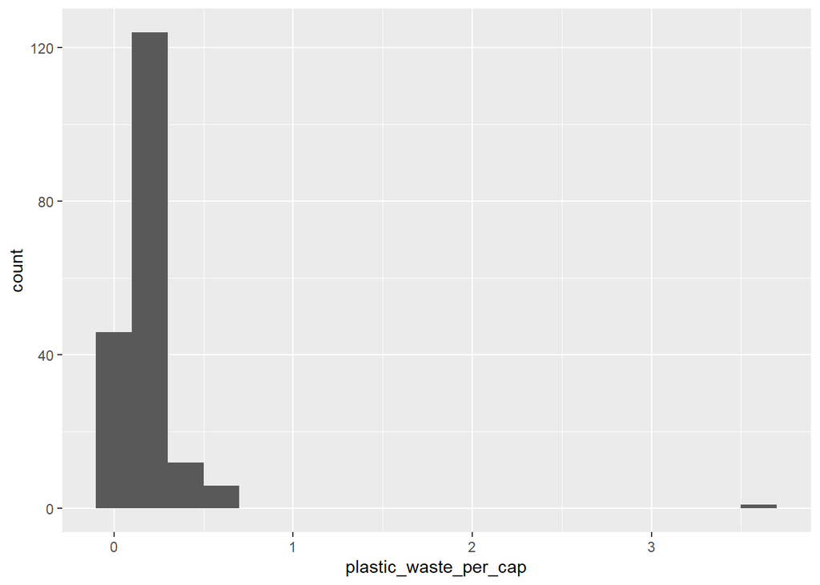

```r
ggplot(data = plastic_waste, aes(x = plastic_waste_per_cap)) +
  geom_histogram(binwidth = 0.2)
```

```r
plastic_waste %>%
  filter(plastic_waste_per_cap > 3.5)
```

```
## # A tibble: 1 x 10
##   code  entity continent  year gdp_per_cap plastic_waste_p~ mismanaged_plas~
##   <chr> <chr>  <chr>     <dbl>       <dbl>            <dbl>            <dbl>
## 1 TTO   Trini~ North Am~  2010      31261.              3.6             0.19
## # ... with 3 more variables: mismanaged_plastic_waste <dbl>, coastal_pop <dbl>,
## #   total_pop <dbl>
```

### Exercise 1

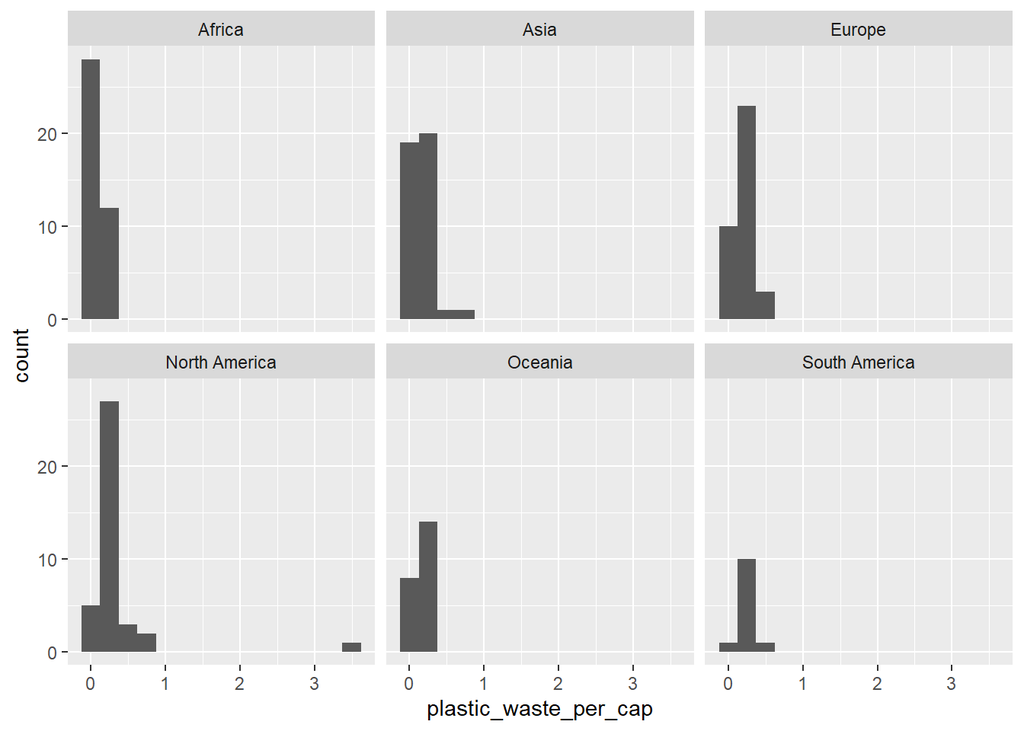

```r
ggplot (data = plastic_waste, aes (x = plastic_waste_per_cap))+
  geom_histogram(binwidth = .25)+
  facet_wrap(~continent)
```

### Exercise 2

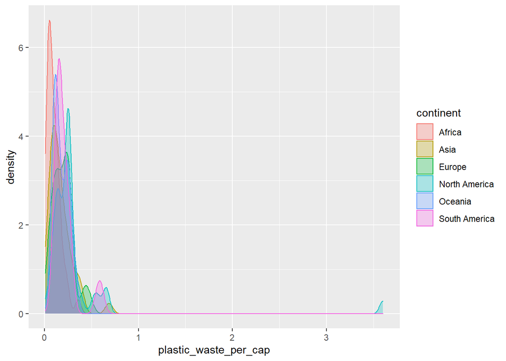

```r
ggplot(data = plastic_waste,
       mapping = aes(x = plastic_waste_per_cap, color = continent, fill = continent)) +
  geom_density(alpha = 0.3)
```

### Exercise 3

I changed the alpha level to 0.3.

### Exercise 4

We defined color and fill by mapping aesthetics because because these determinations are made based on variables in the data. We defined alpha as a characteristic of the plotting geom because this determination was not based on the values or variables in the data.

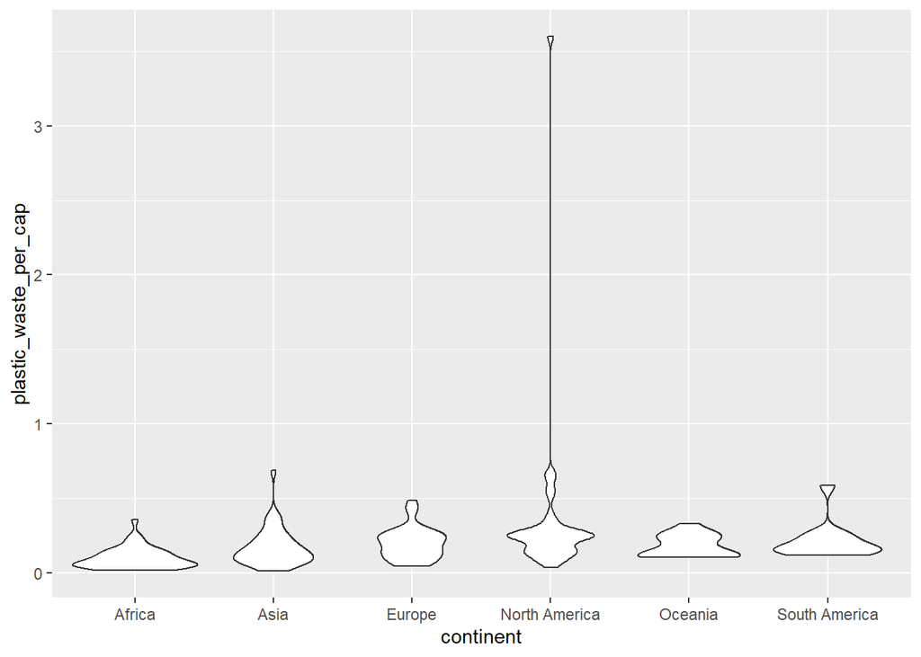

```r
ggplot (data = plastic_waste, mapping = aes (x=continent, y = plastic_waste_per_cap)) +
  geom_violin()
```

### Exercise 5

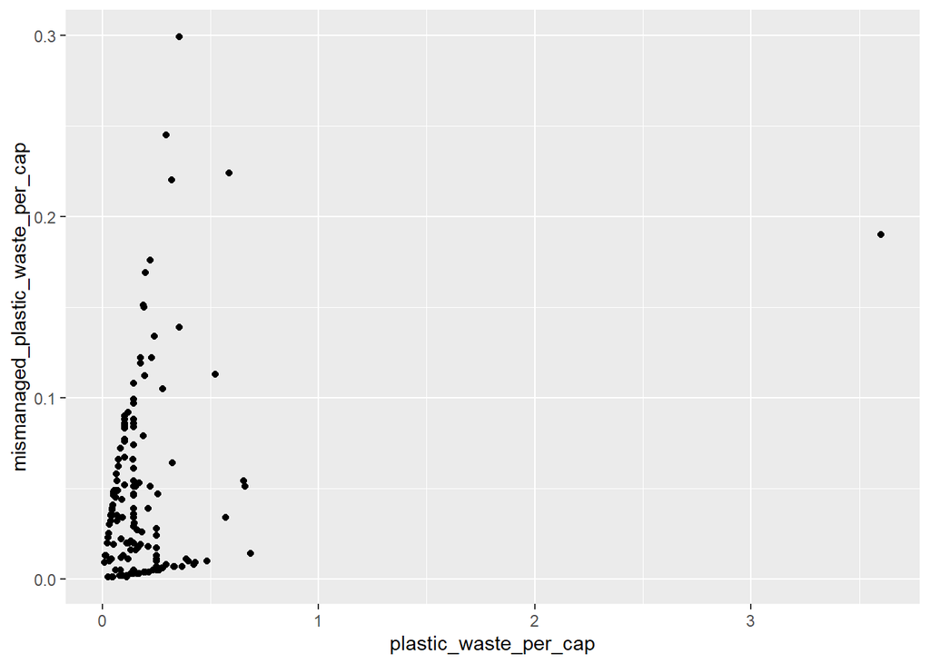

```r
ggplot (data = plastic_waste, aes (x = plastic_waste_per_cap, y = mismanaged_plastic_waste_per_cap))+
  geom_point()
```

### Exercise 6

The scatterplot shows a moderately positive relationship between plastic waste per capita and mismanaged plastic waste per capita. That is, the more plastic waste there is, the more mismanaged the waste becomes.

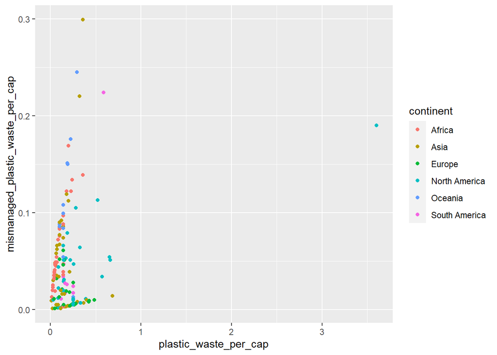

```r
ggplot (data = plastic_waste, aes (x = plastic_waste_per_cap, y = mismanaged_plastic_waste_per_cap, color = continent)) +
  geom_point()
```

### Exercise 7

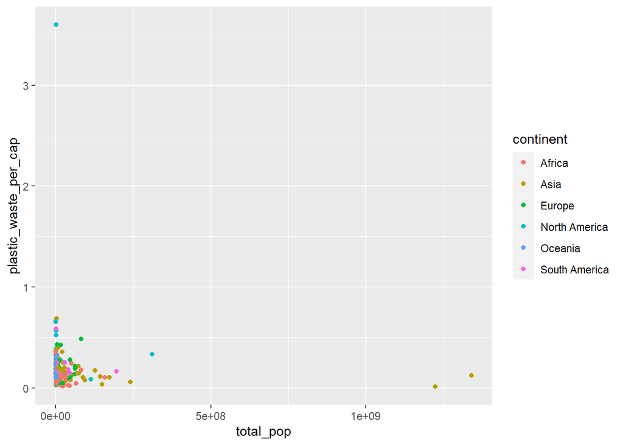

```r
ggplot (data = plastic_waste, aes (x = total_pop, y = plastic_waste_per_cap, color = continent) ) +
  geom_point()
```

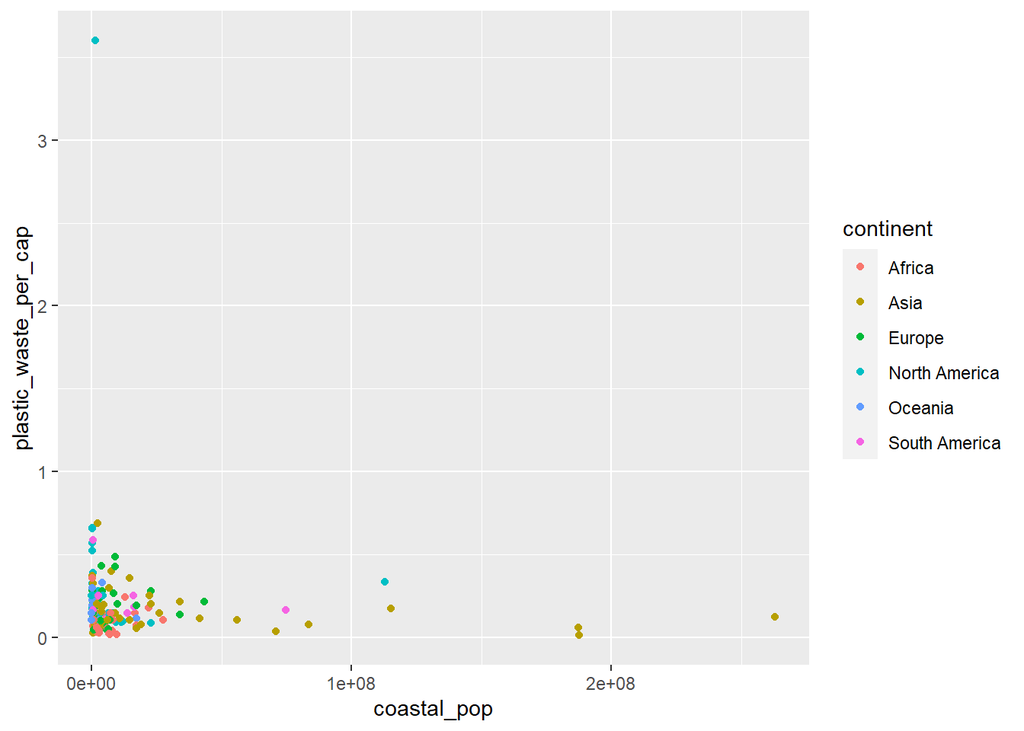

```r
ggplot (data = plastic_waste, aes (x = coastal_pop, y = plastic_waste_per_cap, color = continent)) +
  geom_point()
```

### Exercise 8

The relationship between coastal population and plastic waste per capita appears to be more strongly linearly associated.

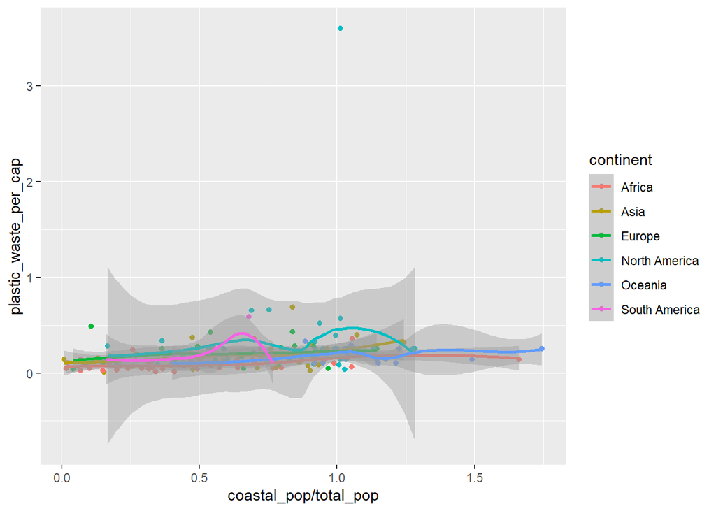

```r
ggplot (data = plastic_waste, aes (x = coastal_pop / total_pop, y = plastic_waste_per_cap, color = continent))+
  geom_point()+
  stat_smooth()
```

This is as close as I could get to the visualization of plastic waste vs. coastal population proportion. It would appear that, as the coastal population reaches the same amount as the total population (in terms of the proportion), there is the most plastic waste per capita.